# Analysis of exposures with an Agent-given discourse context

This notebook analyzes the generalization patterns of novel dative-verb learners based on the factors of exposure contexts which situate the novel verb in a neutral discourse context where only the agent is given. For example:

```
DO: look mommy is walking around . mommy [verbed] me a ball.
PP: look mommy is walking around . mommy [verbed] a ball to me .
```

## Loading Data (code hidden)

```
 Found 255 records...
 Imported 255 records. Simplifying...
```

## Cross Dative Generalization

Investigating alternate-form generalization patterns of the learner when it is exposed to the double object dative vs. prepositional object dative.

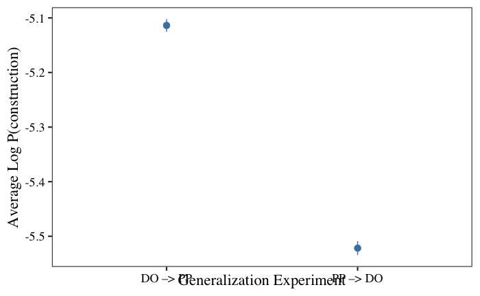

## Conwell’s “me” finding (2019):

Pronominal recipients enable DO comprehension in children, so if we were to believe that comprehension is a precondition to generalization, then pronominal recipients should also encourage generalization:

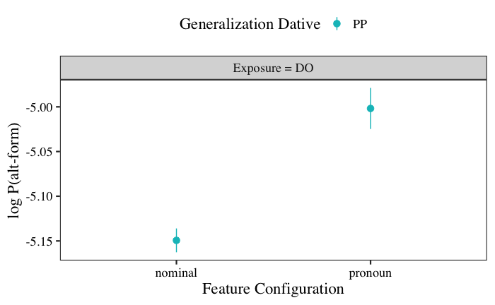

## Replicating Arunachalam (2017):

Only looking at definite themes and recipients:

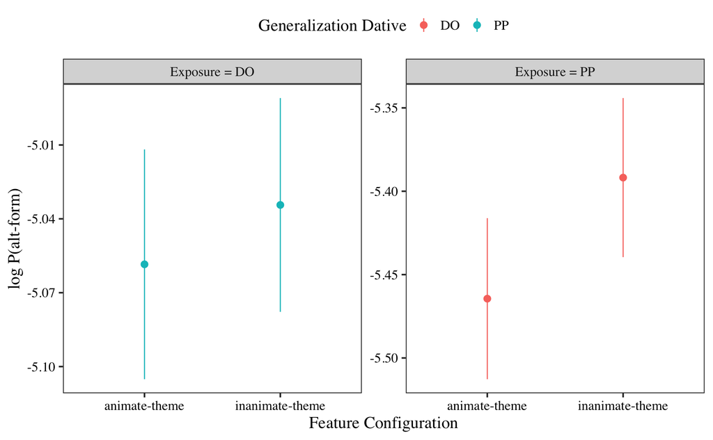

## Interaction terms

The design of interaction terms is a bit tricky. Due to our design, the pronominality might interact with the animacy of a given argument, but animacy and pronominality might also interact across arguments – e.g., if theme is inanimate then LMs might prefer animate recipients (if they are sensitive to the semantics of the dative construction – caused possession/motion). This means we should include the following interaction terms:

```
- theme_animacy * theme_pronominality
- recipient_animacy * recipient_pronominality
- theme_animacy * recipient_animacy
- theme_pronominality * recipient pronominality
```

## DO –> PP analysis

```r
do_pp <- coded_results %>%
  filter(adaptation_dative == "do", generalization_dative == "pp")

# interactions between theme-animacy and recipient animacy; theme-pronominality and recipient-pronominality

fit_tara_tprp_interaction_dopp <- lmer(best ~
                                    theme_animacy + theme_pronominality +
                                    recipient_animacy + recipient_pronominality +
                                    theme_animacy:recipient_animacy +
                                    theme_pronominality:recipient_pronominality +
                                    theme_animacy:theme_pronominality +
                                    recipient_animacy:recipient_pronominality +
                                    theme_definiteness + recipient_definiteness +
                                    theme_length  + recipient_length +
                                    (1|model), data = do_pp)

summary(fit_tara_tprp_interaction_dopp, correlation = FALSE)
```

```
Linear mixed model fit by REML. t-tests use Satterthwaite's method [
lmerModLmerTest]
Formula: best ~ theme_animacy + theme_pronominality + recipient_animacy +
    recipient_pronominality + theme_animacy:recipient_animacy +
    theme_pronominality:recipient_pronominality + theme_animacy:theme_pronominality +
    recipient_animacy:recipient_pronominality + theme_definiteness +
    recipient_definiteness + theme_length + recipient_length +      (1 | model)
   Data: do_pp

REML criterion at convergence: 20586.8

Scaled residuals:
    Min      1Q  Median      3Q     Max
-6.4638 -0.6350  0.0586  0.7298  2.6927

Random effects:
 Groups   Name        Variance Std.Dev.
 model    (Intercept) 0.03919  0.1980
 Residual             0.35267  0.5939
Number of obs: 11400, groups:  model, 10

Fixed effects:
                                              Estimate Std. Error         df
(Intercept)                                 -5.183e+00  6.545e-02  1.059e+01
theme_animacy                               -6.822e-03  1.386e-02  1.138e+04
theme_pronominality                          4.908e-03  1.978e-02  1.138e+04
recipient_animacy                            9.914e-02  1.317e-02  1.138e+04
recipient_pronominality                      1.894e-01  1.961e-02  1.138e+04
theme_definiteness                          -1.928e-02  1.130e-02  1.138e+04
recipient_definiteness                       4.561e-02  1.129e-02  1.138e+04
theme_length                                 5.099e-02  1.304e-02  1.138e+04
recipient_length                             8.203e-02  1.329e-02  1.138e+04
theme_animacy:recipient_animacy             -9.797e-02  2.231e-02  1.138e+04
theme_pronominality:recipient_pronominality  2.344e-01  3.797e-02  1.138e+04
theme_animacy:theme_pronominality            4.249e-02  2.774e-02  1.138e+04
recipient_animacy:recipient_pronominality    3.196e-02  2.630e-02  1.138e+04
                                            t value Pr(>|t|)
(Intercept)                                 -79.191 4.99e-16 ***
theme_animacy                                -0.492   0.6226
theme_pronominality                           0.248   0.8040
recipient_animacy                             7.527 5.59e-14 ***
recipient_pronominality                       9.661  < 2e-16 ***
theme_definiteness                           -1.707   0.0879 .
recipient_definiteness                        4.041 5.36e-05 ***
theme_length                                  3.911 9.24e-05 ***
recipient_length                              6.170 7.04e-10 ***
theme_animacy:recipient_animacy              -4.390 1.14e-05 ***
theme_pronominality:recipient_pronominality   6.174 6.90e-10 ***
theme_animacy:theme_pronominality             1.532   0.1257
recipient_animacy:recipient_pronominality     1.215   0.2243
---
Signif. codes:  0 ‘***’ 0.001 ‘**’ 0.01 ‘*’ 0.05 ‘.’ 0.1 ‘ ’ 1
```

## PP –> DO Analysis

```r
pp_do <- coded_results %>%
  filter(adaptation_dative == "pp", generalization_dative == "do")

fit_tara_tprp_interaction_ppdo <- lmer(best ~
                                    theme_animacy + theme_pronominality +
                                    recipient_animacy + recipient_pronominality +
                                    theme_animacy:recipient_animacy +
                                    theme_pronominality:recipient_pronominality +
                                    theme_animacy:theme_pronominality +
                                    recipient_animacy:recipient_pronominality +
                                    theme_definiteness + recipient_definiteness +
                                    theme_length  + recipient_length +
                                    (1|model), data = pp_do)

summary(fit_tara_tprp_interaction_ppdo, correlation = FALSE)
```

```
Linear mixed model fit by REML. t-tests use Satterthwaite's method [
lmerModLmerTest]
Formula: best ~ theme_animacy + theme_pronominality + recipient_animacy +
    recipient_pronominality + theme_animacy:recipient_animacy +
    theme_pronominality:recipient_pronominality + theme_animacy:theme_pronominality +
    recipient_animacy:recipient_pronominality + theme_definiteness +
    recipient_definiteness + theme_length + recipient_length +      (1 | model)
   Data: pp_do

REML criterion at convergence: 22472.2

Scaled residuals:
    Min      1Q  Median      3Q     Max
-5.5948 -0.6407  0.0694  0.7404  2.9425

Random effects:
 Groups   Name        Variance Std.Dev.
 model    (Intercept) 0.03893  0.1973
 Residual             0.41623  0.6452
Number of obs: 11400, groups:  model, 10

Fixed effects:
                                              Estimate Std. Error         df
(Intercept)                                 -5.817e+00  6.575e-02  1.090e+01
theme_animacy                               -7.075e-02  1.506e-02  1.138e+04
theme_pronominality                          1.436e-01  2.149e-02  1.138e+04
recipient_animacy                            3.692e-02  1.431e-02  1.138e+04
recipient_pronominality                     -2.230e-02  2.130e-02  1.138e+04
theme_definiteness                           1.415e-02  1.227e-02  1.138e+04
recipient_definiteness                       4.204e-02  1.226e-02  1.138e+04
theme_length                                 2.636e-01  1.416e-02  1.138e+04
recipient_length                             1.650e-01  1.444e-02  1.138e+04
theme_animacy:recipient_animacy             -4.762e-02  2.424e-02  1.138e+04
theme_pronominality:recipient_pronominality  1.547e-01  4.125e-02  1.138e+04
theme_animacy:theme_pronominality           -1.500e-01  3.014e-02  1.138e+04
recipient_animacy:recipient_pronominality   -6.083e-02  2.857e-02  1.138e+04
                                            t value Pr(>|t|)
(Intercept)                                 -88.468  < 2e-16 ***
theme_animacy                                -4.698 2.66e-06 ***
theme_pronominality                           6.686 2.41e-11 ***
recipient_animacy                             2.580 0.009890 **
recipient_pronominality                      -1.047 0.295006
theme_definiteness                            1.153 0.248984
recipient_definiteness                        3.429 0.000608 ***
theme_length                                 18.616  < 2e-16 ***
recipient_length                             11.423  < 2e-16 ***
theme_animacy:recipient_animacy              -1.964 0.049522 *
theme_pronominality:recipient_pronominality   3.749 0.000178 ***
theme_animacy:theme_pronominality            -4.979 6.50e-07 ***
recipient_animacy:recipient_pronominality    -2.129 0.033283 *
---
Signif. codes:  0 ‘***’ 0.001 ‘**’ 0.01 ‘*’ 0.05 ‘.’ 0.1 ‘ ’ 1
```

## Attempt at displaying DO -> PP and PP -> DO in same table:

```r
tidy(fit_tara_tprp_interaction_dopp) %>%
  filter(effect == "fixed") %>%
  select(term, do_pp_estimate = estimate, do_pp_pval = p.value) %>%
  inner_join(
    tidy(fit_tara_tprp_interaction_ppdo) %>%
      filter(effect == "fixed") %>%
      select(term, pp_do_estimate = estimate, pp_do_pval = p.value)
  ) %>%
  mutate(
    # do_pp_estimate = format(do_pp_estimate , scientific=TRUE),
    # pp_do_estimate = format(pp_do_estimate, scientific=TRUE),
    do_pp_estimate = round(do_pp_estimate, 4),
    pp_do_estimate = round(pp_do_estimate, 4),
    do_pp_signif = case_when(
      do_pp_pval < 0.05 ~ "**",
      TRUE ~ as.character(round(do_pp_pval, 4))
    ),
    pp_do_signif = case_when(
      pp_do_pval < 0.05 ~ "**",
      TRUE ~ as.character(round(pp_do_pval, 4))
    )
  ) %>%
  select(term, do_pp_estimate, do_pp_signif, pp_do_estimate, pp_do_signif) %>%
  DT::datatable(options = list(pageLength = 14))
```

|  | term | do_pp_estimate | do_pp_signif | pp_do_estimate | pp_do_signif |
| --- | --- | --- | --- | --- | --- |
| 1 | (Intercept) | -5.1833 | ** | -5.8172 | ** |
| 2 | theme_animacy | -0.0068 | 0.6226 | -0.0707 | ** |
| 3 | theme_pronominality | 0.0049 | 0.804 | 0.1436 | ** |
| 4 | recipient_animacy | 0.0991 | ** | 0.0369 | ** |
| 5 | recipient_pronominality | 0.1894 | ** | -0.0223 | 0.295 |
| 6 | theme_definiteness | -0.0193 | 0.0879 | 0.0141 | 0.249 |
| 7 | recipient_definiteness | 0.0456 | ** | 0.042 | ** |
| 8 | theme_length | 0.051 | ** | 0.2636 | ** |
| 9 | recipient_length | 0.082 | ** | 0.165 | ** |
| 10 | theme_animacy:recipient_animacy | -0.098 | ** | -0.0476 | ** |

[output cut: 3 more lines]